# Project Draft

Alex Beal

November 16, 2018

# Is Water Temperature Contributing to The Declining Beluga Whale Populations?

## Introduction/Background:

Beluga Whales or Delphinapterus leucas are whales with a easily identifiable white color and they most commonly reside in the Arctic Ocean’s coastal waters. These arctic belugas migrate south in large herds once the ocean freezes over (O’Corry-Crowe et al., 2016). Belugas reside in various locations around the arctic circle. One of these locations is the Cook Inlet in Alaska which is home to a sizable population of beluga whales. This population of beluga whales has been declining for nearly four to five decades (Hobbs et al., 2006). The Cook Inlet beluga whales were listed under the endangered species list as of 2008 and are still endangered now (Hobbs et al., 2006). There are various hypothesis that might explain the contraction of the whales. The first being habitat change, avoidance of predators, followed by the limited optimal habitat space for the belugas. (Shelden et al., 2010). This can range from prey availability to water temperature. Looking at the first hypothesis, habitat change, water temperature can be a change that can cause the whales to move locations. Although even local fishermen are noticing a difference in the whales which might be related to the increased water temperature (Brain et al., 2010). There have also been an increase of sharks in the northern portions of the inlet which they attribute to warmer waters and that can also be an indication as to why belugas are moving farther north as well (Carter et al., 2010). They indicate the reason for the sharks moving into the upper inlet to be due to warmer waters although there could be other reasons. A common reason could be that the sharks are simply following their prey as they move farther into the upper inlet. There has always been a decline in the number of beluga whales but there was a very steep decrease which can be attributed to hunting. The National Marine Fisheries Service between 1994 and 1998 began to take aerial surveys of the belugas which showed a decline (Hobbs et al., 2006). There have been various claims made in regards to population size although most have not been backed up by sources and or studies/surveys. The Alaska Department of Fish and Game surveyed a total number of 479 belugas but this was not even considered a complete survey (Vos et al., 2006). Belugas are no longer being hunted by humans although they still have natural predators specifically Killer Whales. The Killer Whales are more commonly found in the lower Cook Inlet which has been forcing the belugas toward the upper inlet (Barbara et al., 2003). Although there have been orcas sighted within the upper portion of the inlet. (Barbara et al., 2003). Killer whales are hunting the belugas but due to sightings all around the inlet, lower and upper, we can’t attribute the belugas moving to the upper inlet solely on killer whales. It has been observed that more belugas have been sighted on the upper inlet rather than more coastal waters where they had frequented in the past (Goetz et al., 2012). The belugas seem to be moving farther north into the inlet where there is warmer water. The Cook Inlet Belugas are different from other belugas due to their location. In comparison to other Alaska and Russian beluga populations in the arctic, the Cook Inlet whales do not disperse into the Bering Sea nor do they seem to have a seasonal migration as other whales more commonly have (Hobbs et al., 2006). The whales seem to stay in the Inlet which allows us to observe them easier and be able to study them. Belugas also travel in pods which can range from 3 to 25 but usually there are 10 in a pod. When surveying this makes it easier to count and get an estimate of population size of how many beluga are in a given area. The distribution and location of the whales have spread to the upper inlet area and the coastal shores (Rugh et al., 2010). Are warmer water temperatures directly affecting life for Beluga Whales living in the Cook Inlet, Alaska? Looking into the data collected by the National Marine Fisheries Service regarding beluga numbers with specific dates and locations I can correlate that will the water temperature in the upper inlet area. This will show if the water temperature is affecting the declining population of the beluga whales in Cook Inlet, Alaska.

## Data Gathering Methods:

The data obtained by the National Marine Fisheries Service (NMFS) is being used to analyze the declining population size in the Cook Inlet. The number of beluga whales in the upper inlet are greater than most areas and there is a much larger sample size. The larger sample size and the trend that the whales are moving toward the upper inlet leads me to believe that is where we can accurately see the correlation between water temperature and how it affect the population of belugas. That is why I have chosen to look specifically at the data correlating to the location of Susitna. Susitna is a greater portion of the upper inlet which has a dense population of belugas. Using this data paired with the data obtained from the National Oceanic and Atmospheric Administration regarding water temperature in Anchorage, I will be able to see if there is a correlation between water temperature and the declining beluga population. From all of the Susitna data, there were two columns for counts. Each is correlated to a column stating if the data is good or not. I simply took the specific count if it was usable data. If both sets of data are good then I find the mean of the two. I will be using data from 8/16-17/2006, 8/1/2007, 8/13-14/2008, 8/11,13/2009, 8/9/2011, and 8/7-9/2012 along with the corresponding water temp levels. I chose to narrow it down to just one month of each year due to the same size. Adding the water temperature to the count data was done by getting the average temp for a given day and then transferring that data into the count dataset. Once that has been completed we can begin to create visuals and graphs of the data.

## Metadata Notes:

I am using data gathered by the National Marine Fisheries Service (NMFS) which conducted aerial counts of Cook Inlet Beluga Whales from 1993 to 2014. The specific data that I will be using is the aerial counts of the beluga whale groups which is recorded and organized as a daily index. The aerial surveys were flown in a twin engine aircraft that had the capability of flying for greater than six hours. Each one of the surveys ranged between 3 - 9 days which included coastal and offshore traversals. During the surveying there was an aerial observer that counts the belugas which is used to calculate median counts for each beluga group. There was also footage of the whales in order to get a more accurate count or even with the observer might not have a complete visual of the pod. The observer also counts corrected for perception and availability bias are also used in abundance estimates when the video is not available. There is more than enough data to suffice for this analysis with over 1500 data points of the group of beluga, the count, date as well as how the count was made. Additionally there are groups associated with each observation which can be then placed at a location in the Cook Inlet. We then can look at water temperature in that area at the time and see if there is a correlation. Specifically I am using the file entitled, “MasterCIBAerialObsCountsPARR.cvs”, and I have taken only the data pertaining to Susitna. Data: https://data.nodc.noaa.gov/cgi-bin/iso?id=gov.noaa.nodc:0133936

The water temperature data that I obtained is from the National Oceanic and Atmospheric Administration. These data was collected by the Anchorage, AK collecting station (Station ID: 9455920). This station was installed on August 07, 1991 and has been operating since then. I collected my data by entering in the year and date for the desired temperature. There are stations nearby that I could have used rather than Anchorage but due to the larger population size seen farther up toward the upper inlet Anchorage is the best location.

## Data

### Cleaning Data

The whole dataset that I started with had 4813 entries. A good majority of my data was not useable due to complications in the weather, incomplete data, and location. Since my articlces were all pointing toward the populations within the upper inlet, I decided to analyze the population sizes of the belugas in the upper inlet. More specifically I decided to look into the Susitna area within the upper inlet. This is because there was an adequate sample size to analyze. Now I went through the Susitna data and if there were any notes stating that the data was not useable I took that row out. Similarly if the data was blank or incomplete I removed that row as well. Once all of the blank fields were taken out and I had data to work with I began averaging out the data. Meaning there are two counts that were taken and if one count was not specified as the count to use, I averaged the two counts and used that as my final count. I was able to use NOAA resources to find all of the water data I needed, even specifying day, month, and year. I then joined the water data corresponding with the dates of the finalCount. After that I removed all columns except date, finalCount, groupNumber, and waterTemp.

### Analysis Data

Looking at my overall data unfortunately the data is not entirely normal and looking at the histogram it is clear to see that. The qqplot is looking better but the overall data is not very normalized.

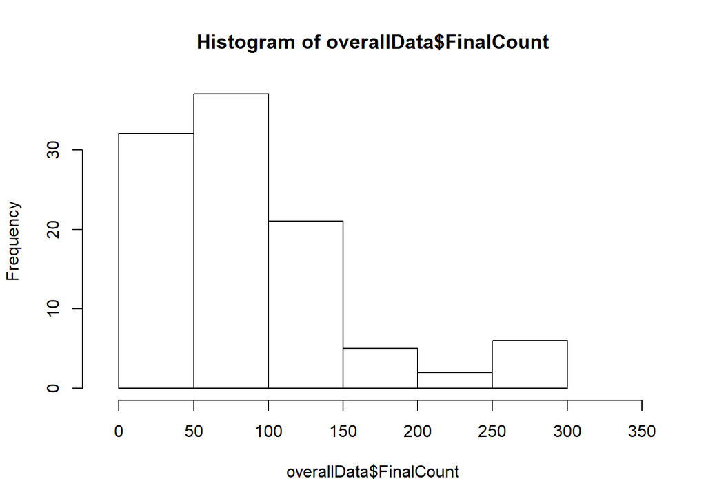

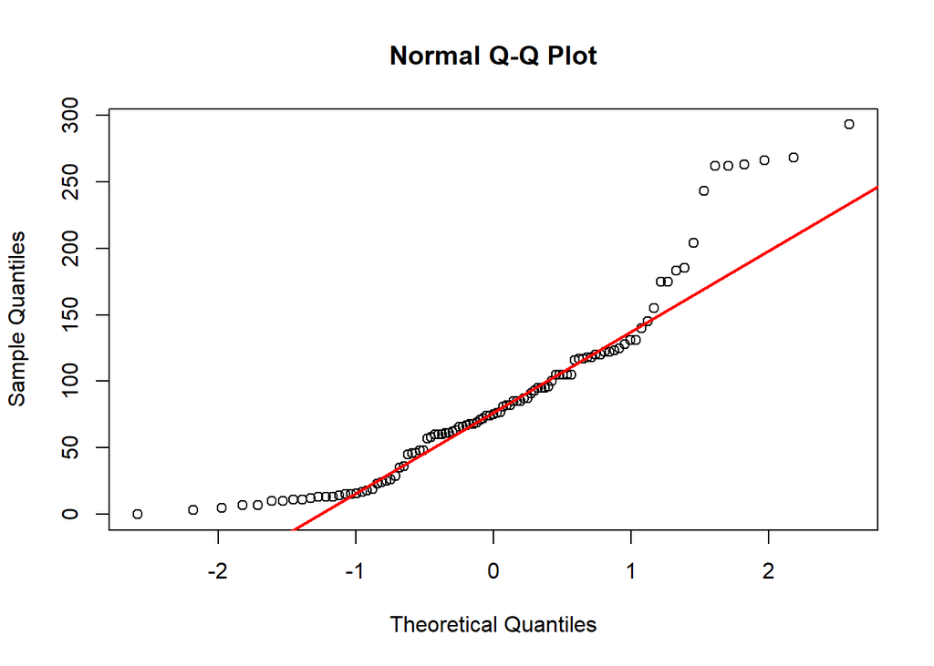

The specific pod data is similar to the overall data although the qqplot is more normalized but the histogram shows almost no normality.

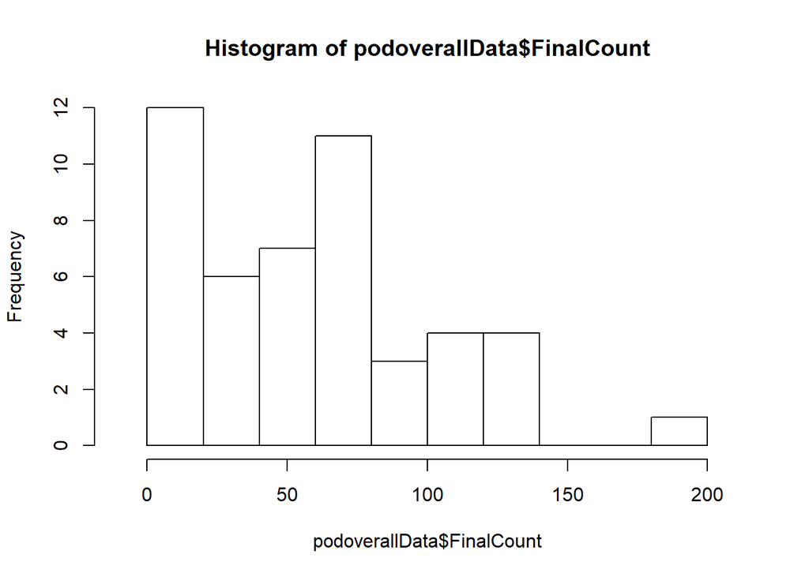

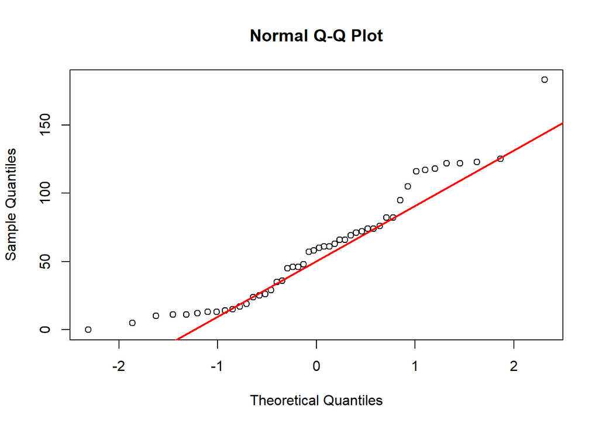

Moving forward knowing the data is not completely normalized we will look into the Power T Tests. Although before we need to figure out or Cohen’s D to accurately get a signifigance level. Here is the script used to solve for Cohen’s D where x is the count and y is the water temperture.

```r
x <- overallData$FinalCount
y <- overallData$WaterTemp

cohens_d <- function(x, y) {
  lx <- length(x)
  ly <- length(y)
  md  <- abs(mean(x) - mean(y))
  csd <- lx * var(x) + ly * var(y)
  csd <- csd/(lx + ly)
  csd <- sqrt(csd)
  cd  <- md/csd
}
res <- cohens_d(x, y)
```

```r
#Overall T Test
pwr.t.test(n = 103, sig.level = NULL, power = 0.1, d = .6, type = "two.sample", alternative = 'greater')
```

```
##
##      Two-sample t test power calculation
##
##               n = 103
##               d = 0.6
##       sig.level = 1e-10
##           power = 0.1
##     alternative = greater
##
## NOTE: n is number in *each* group
```

```r
#Pod T Test
pwr.t.test(n = 48, sig.level = NULL, power = 0.1, d = .1, type = "two.sample", alternative = 'greater')
```

```
##
##      Two-sample t test power calculation
##
##               n = 48
##               d = 0.1
##       sig.level = 0.03859232
##           power = 0.1
##     alternative = greater
##
## NOTE: n is number in *each* group
```

Now looking into the linear regression for both of these data to see if there is a level of significance between water temp and the final count.

Looking at the overall data we see that there is not a high enough significance to conclude that water temperature is correlated to the declining population of belugas.

```
##
## Call:
## lm(formula = overallData$FinalCount ~ overallData$WaterTemp)
##
## Residuals:
##    Min     1Q Median     3Q    Max
## -86.62 -48.26 -12.62  30.38 206.38
##
## Coefficients:
##                       Estimate Std. Error t value Pr(>|t|)
## (Intercept)           -234.018    460.288  -0.508    0.612
## overallData$WaterTemp    5.726      8.220   0.697    0.488
##
## Residual standard error: 67.28 on 101 degrees of freedom
## Multiple R-squared:  0.004781,   Adjusted R-squared:  -0.005073
## F-statistic: 0.4852 on 1 and 101 DF,  p-value: 0.4877
```

The specific pod data however does show some significance. Although with all of the contributing factors for the declining population I cannot confidently say that there is a direct correlation between water temperature and the declining population.

```
##
## Call:
## lm(formula = podoverallData$FinalCount ~ podoverallData$WaterTemp)
##
## Residuals:
##     Min      1Q  Median      3Q     Max
## -68.118 -24.107  -3.618  21.893 114.882
##
## Coefficients:
##                          Estimate Std. Error t value Pr(>|t|)
## (Intercept)              -1738.47     693.00  -2.509   0.0157 *
## podoverallData$WaterTemp    32.26      12.44   2.593   0.0127 *
## ---
## Signif. codes:  0 '***' 0.001 '**' 0.01 '*' 0.05 '.' 0.1 ' ' 1
##
## Residual standard error: 39.17 on 46 degrees of freedom
## Multiple R-squared:  0.1276, Adjusted R-squared:  0.1086
## F-statistic: 6.726 on 1 and 46 DF,  p-value: 0.0127
```

### Bibliography:

Hobbs, R. C., K. E. W. Shelden, D. J. Vos, K. T. Goetz, and D. J. Rugh. 2006. Status review and extinction assessment of Cook Inlet belugas (Delphinapterus leucas). AFSC Processed Rep. 16:74.

Rugh, D.J., K. E. W. Shelden, and R. C. Hobbs. 2010. Range contraction in a beluga whale population. Endangered Species Research 12:69-75.

Carter, T. G. B. and E. A. Nielsen. 2010. Exploring ecological changes in Cook Inlet beluga whale habitat though traditional and local ecological knowledge of contributing factors for population decline. Marine Policy 35:299-308

Shelden, K. E. W., B. A. Mahoney, D. J. Rugh and M. E. Dahlheim. 2006. Killer Whale Predation on Belugas in Cook Inlet, Alaska: Implications For a Depleted Population. Marine Animal Science 19:529-544

Goetz, K. T., R. A. Montgomery, J. M. Ver Hoef, R. C. Hobbs and D. S. Johnson. 2012. Identifying essential summer habitat of endangered beluga whale Delphinapterus leucas in Cook Inlet, Alaska. Endangered Species Research 16:135-147

O’Corry-Crowe, G., A. R. Mahoney, R. Suydam, L. Quakenbush, A. Whiting, L. Lowry and L. Harwood. 2016. Genetic Profiling links changing sea-ice to shifting beluga whale migration patterns. Biology Letters DOI: 10.1098/rsbl.2016.0404